# Introductory Applied Machine Learning

## Lab 3: Decision Trees dan Evaluasi

Dalam modul ini, Anda akan mempelajari bagaimana melakukan klasifikasi dengan menggunakan *decision trees*. Untuk memastikan bahwa algoritma *machine learning* yang Anda gunakan memberikan kinerja yang optimal, Anda juga akan belajar untuk melakukan *hyperparameter tuning*. Terakhir, Anda juga diminta membuat kurva ROC sebagai alternatif dari pengukuran kinerja model yang dibentuk dengan *machine learning*.

## Daftar isi

- Decision Trees
- Evaluasi

```python
import matplotlib.pyplot as plt
import numpy as np
import pandas as pd
import seaborn as sns
import warnings
%matplotlib inline

plt.style.use('fivethirtyeight')
warnings.filterwarnings("ignore")

RANDOM_STATE = 911
```

## Decision Trees

Dalam kasus ini, kita akan menggunakan data Titanic. Deskripsi dari dataset ini bisa dilihat di [sini](https://www.kaggle.com/c/titanic/data).

```python
df = sns.load_dataset('titanic')
df.head()
```

|  | survived | pclass | sex | age | sibsp | parch | fare | embarked | class | who | adult_male | deck | embark_town | alive | alone |
| --- | --- | --- | --- | --- | --- | --- | --- | --- | --- | --- | --- | --- | --- | --- | --- |
| 0 | 0 | 3 | male | 22.0 | 1 | 0 | 7.2500 | S | Third | man | True | NaN | Southampton | no | False |
| 1 | 1 | 1 | female | 38.0 | 1 | 0 | 71.2833 | C | First | woman | False | C | Cherbourg | yes | False |
| 2 | 1 | 3 | female | 26.0 | 0 | 0 | 7.9250 | S | Third | woman | False | NaN | Southampton | yes | True |
| 3 | 1 | 1 | female | 35.0 | 1 | 0 | 53.1000 | S | First | woman | False | C | Southampton | yes | False |
| 4 | 0 | 3 | male | 35.0 | 0 | 0 | 8.0500 | S | Third | man | True | NaN | Southampton | no | True |

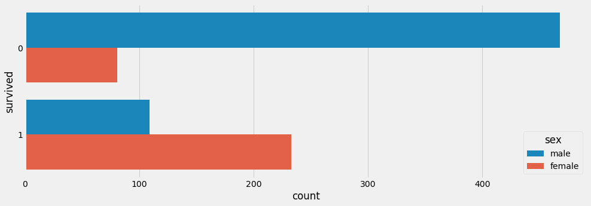

```python
fig, ax = plt.subplots(figsize=(15,5))
sns.countplot(y='survived', hue='sex', data=df, ax=ax)
plt.show()
```

## Decision Trees

Dalam pustaka scikit-learn yang digunakan dalam modul praktikum ini, implementasi dari decision trees yang diberikan hanya satu jenis. Jenis pohon yang digunakan adalah CART yang teroptimasi. Silakan lihat dokumentasinya di [sini](http://scikit-learn.org/stable/modules/tree.html). Berbeda dengan Naive Bayes, ada lebih banyak *hyperparameters* yang harus disesuaikan dalam algoritma Decision Trees.

```python
X = df[['pclass', 'sex', 'age', 'fare', 'embarked', 'alone']]
X[X.isnull().any(axis=1)]
```

|  | pclass | sex | age | fare | embarked | alone |
| --- | --- | --- | --- | --- | --- | --- |
| 5 | 3 | male | NaN | 8.4583 | Q | True |
| 17 | 2 | male | NaN | 13.0000 | S | True |
| 19 | 3 | female | NaN | 7.2250 | C | True |
| 26 | 3 | male | NaN | 7.2250 | C | True |
| 28 | 3 | female | NaN | 7.8792 | Q | True |
| 29 | 3 | male | NaN | 7.8958 | S | True |
| 31 | 1 | female | NaN | 146.5208 | C | False |
| 32 | 3 | female | NaN | 7.7500 | Q | True |
| 36 | 3 | male | NaN | 7.2292 | C | True |
| 42 | 3 | male | NaN | 7.8958 | C | True |
| 45 | 3 | male | NaN | 8.0500 | S | True |
| 46 | 3 | male | NaN | 15.5000 | Q | False |
| 47 | 3 | female | NaN | 7.7500 | Q | True |
| 48 | 3 | male | NaN | 21.6792 | C | False |
| 55 | 1 | male | NaN | 35.5000 | S | True |
| 61 | 1 | female | 38.0 | 80.0000 | NaN | True |
| 64 | 1 | male | NaN | 27.7208 | C | True |
| 65 | 3 | male | NaN | 15.2458 | C | False |
| 76 | 3 | male | NaN | 7.8958 | S | True |
| 77 | 3 | male | NaN | 8.0500 | S | True |
| 82 | 3 | female | NaN | 7.7875 | Q | True |
| 87 | 3 | male | NaN | 8.0500 | S | True |
| 95 | 3 | male | NaN | 8.0500 | S | True |
| 101 | 3 | male | NaN | 7.8958 | S | True |
| 107 | 3 | male | NaN | 7.7750 | S | True |
| 109 | 3 | female | NaN | 24.1500 | Q | False |
| 121 | 3 | male | NaN | 8.0500 | S | True |
| 126 | 3 | male | NaN | 7.7500 | Q | True |
| 128 | 3 | female | NaN | 22.3583 | C | False |
| 140 | 3 | female | NaN | 15.2458 | C | False |
| ... | ... | ... | ... | ... | ... | ... |
| 727 | 3 | female | NaN | 7.7375 | Q | True |
| 732 | 2 | male | NaN | 0.0000 | S | True |
| 738 | 3 | male | NaN | 7.8958 | S | True |
| 739 | 3 | male | NaN | 7.8958 | S | True |
| 740 | 1 | male | NaN | 30.0000 | S | True |
| 760 | 3 | male | NaN | 14.5000 | S | True |
| 766 | 1 | male | NaN | 39.6000 | C | True |
| 768 | 3 | male | NaN | 24.1500 | Q | False |
| 773 | 3 | male | NaN | 7.2250 | C | True |
| 776 | 3 | male | NaN | 7.7500 | Q | True |
| 778 | 3 | male | NaN | 7.7375 | Q | True |
| 783 | 3 | male | NaN | 23.4500 | S | False |
| 790 | 3 | male | NaN | 7.7500 | Q | True |
| 792 | 3 | female | NaN | 69.5500 | S | False |
| 793 | 1 | male | NaN | 30.6958 | C | True |
| 815 | 1 | male | NaN | 0.0000 | S | True |
| 825 | 3 | male | NaN | 6.9500 | Q | True |
| 826 | 3 | male | NaN | 56.4958 | S | True |
| 828 | 3 | male | NaN | 7.7500 | Q | True |
| 829 | 1 | female | 62.0 | 80.0000 | NaN | True |
| 832 | 3 | male | NaN | 7.2292 | C | True |
| 837 | 3 | male | NaN | 8.0500 | S | True |
| 839 | 1 | male | NaN | 29.7000 | C | True |
| 846 | 3 | male | NaN | 69.5500 | S | False |
| 849 | 1 | female | NaN | 89.1042 | C | False |
| 859 | 3 | male | NaN | 7.2292 | C | True |
| 863 | 3 | female | NaN | 69.5500 | S | False |
| 868 | 3 | male | NaN | 9.5000 | S | True |
| 878 | 3 | male | NaN | 7.8958 | S | True |
| 888 | 3 | female | NaN | 23.4500 | S | False |

179 rows × 6 columns

Perhatikan bahwa ada banyak nilai `age` yang kosong. Untuk itu, kita perlu mengganti nilai tersebut (*impute*). Salah satu opsi nilai pengganti adalah dengan median atau mean.

```python
X.age.median()
```

```
28.0
```

```python
X['age'] = X.age.fillna(X.age.median())
```

```python
from sklearn.model_selection import GridSearchCV, train_test_split
from sklearn.preprocessing import LabelEncoder

le = LabelEncoder()

y = df['survived']

X['sex'] = le.fit_transform(X['sex'])
X['alone'] = le.fit_transform(X['alone'])
X = pd.concat([X, pd.get_dummies(X.embarked)], axis=1)
del X['embarked']

X_train, X_test, y_train, y_test = train_test_split(X, y, test_size=0.33, random_state=RANDOM_STATE)
```

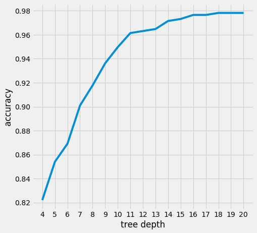

```python
from sklearn.ensemble import RandomForestClassifier, GradientBoostingClassifier
from sklearn.tree import DecisionTreeClassifier
from sklearn.metrics import accuracy_score, confusion_matrix

acc = []
for depth in range(4,21):
    clf = DecisionTreeClassifier(max_depth=depth)
    clf.fit(X_train, y_train)
    y_pred = clf.predict(X_train)
    acc.append(accuracy_score(y_train, y_pred))

fig, ax = plt.subplots(figsize=(7,7))
ax.plot(range(4,21), acc)
ax.set_xlabel('tree depth')
ax.set_ylabel('accuracy')
ax.set_xticks(range(4,21));
```

Apakah nilai akurasinya akan mencapai 100%?

### Hyperparameter Tuning

```python
# Kode diadaptasi dari http://ahmedbesbes.com/how-to-score-08134-in-titanic-kaggle-challenge.html

clf = DecisionTreeClassifier()

parameter_grid = {
    'max_depth' : [4,5,6,7,8],
    'criterion': ['gini','entropy']
}

grid_search = GridSearchCV(clf,
                           scoring='accuracy',
                           param_grid=parameter_grid,
                           cv=10)

grid_search.fit(X_train, y_train)

print('Best accuracy: {:.2%}'.format(grid_search.best_score_))
print('Best parameters: {}'.format(grid_search.best_params_))
```

```
Best accuracy: 80.03%
Best parameters: {'criterion': 'entropy', 'max_depth': 6}
```

## Evaluasi

```
Akurasi: 76.95%
Confusion matrix
```

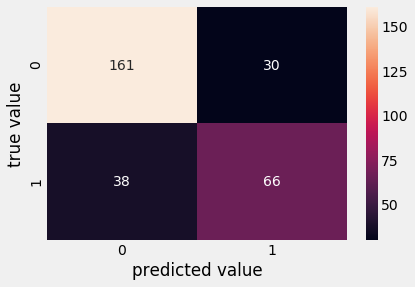

```python
y_pred = grid_search.predict(X_test)

print("Akurasi: {:.2%}".format(accuracy_score(y_test, y_pred)))
print("Confusion matrix")
sns.heatmap(confusion_matrix(y_test, y_pred), annot=True, fmt='d')
plt.ylabel('true value')
plt.xlabel('predicted value');
```

### ROC Curve

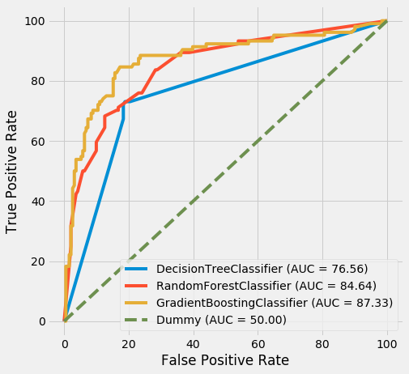

```python
from sklearn.metrics import roc_curve, roc_auc_score

clfs = [
    DecisionTreeClassifier,
    RandomForestClassifier,
    GradientBoostingClassifier
]

fig, ax = plt.subplots()
fig.set_size_inches(7,7)

for clf in clfs:
    c = clf()
    c.fit(X_train, y_train)
    score = c.predict_proba(X_test)
    fpr, tpr, thresholds = roc_curve(y_test, score[:,1])
    auc = roc_auc_score(y_test, score[:,1])
    ax.plot(fpr*100, tpr*100, label='{} (AUC = {:.2f})'.format(clf.__name__, auc*100))

ax.set_xlabel('False Positive Rate')
ax.set_ylabel('True Positive Rate')
ax.plot([0,100], [0,100], label='Dummy (AUC = 50.00)', linestyle='--')
ax.legend(loc=4)
plt.show()
```

*Dummy classifier* dalam kasus ini dihasilkan dengan memprediksi data uji berdasarkan probabilitas kelas *prior* dari data latih.